# Oscars Statistics Project

Benjamin Morris

Due Monday 2015/5/11 8:30am on GitHub

In this project, I have sought to examine the potential for bias in prestige assessments in the film industry. This project examines individuals that have been nominated for and those who have won Academy Awards in either acting or writing. In particular, I seek to address prevailing myths about biases in film recognition. One such myth is that actors who win the Oscar for Best Actress are significantly younger than actors winning for the Best Actor category. Other factors of interest include measures of a film’s prestige overall and the film’s production budget. Bias is undoubtedly present in the recognition of actors’ and film makers’ accomplishments. I have attempted to expose some of that bias by illustrating patterns that underlie one’s potential success at award ceremonies.

### Data Wrangling

#### Data Before Cleaning:

| Year | Actress | Film | Role(s) | Ref. |
| --- | --- | --- | --- | --- |
| 1927/28(1st) | Janet Gaynor | 7th HeavenStreet AngelSunrise: A Song of Two Humans | Diane |  |
| Angela |  |  |  |  |
| The Wife [9] |  |  |  |  |
| Louise Dresser | A Ship Comes In | Mrs. Pleznik | NA | NA |
| Gloria Swanson | Sadie Thompson | Sadie Thompson | NA | NA |
| 1928/29(2nd) | Mary Pickford | Coquette | Norma Besant | [10] |
| Ruth Chatterton | Madame X | Jacqueline Floriot | NA | NA |
| Betty Compson | The Barker | Carrie | NA | NA |

- (Some of) The Issues:
  - Columns shifted over during scraping.
  - Year cells spanned multiple rows of the original table, scraping put them in as unique rows of the Name variable. Thus we have no distinct year variable and we have extra entries in the name variable.
  - Year variable also includes the ceremony number.
  - The winner for a given year is denoted by being the first row of that year. We need a distinct variable.
  - The early years of many awards allowed for more or fewer than 5 individuals to be nominated, which creates issues for subsequent coding which relies on a consistent number of rows per year.

#### Data After Cleaning:

|  | Year | Name | Movie | Award | Win |
| --- | --- | --- | --- | --- | --- |
| 2 | 1936 | Luise Rainer | The Great Ziegfeld | Actress | Won |
| 3 | 1936 | Irene Dunne | Theodora Goes Wild | Actress | Lost |
| 4 | 1936 | Gladys George | Valiant Is the Word for Carrie | Actress | Lost |
| 5 | 1936 | Carole Lombard | My Man Godfrey | Actress | Lost |
| 6 | 1936 | Norma Shearer | Romeo and Juliet | Actress | Lost |
| 8 | 1937 | Luise Rainer | The Good Earth | Actress | Won |

### Regression Equation

```r
model <- glm(Win ~ budget + rating, family = binomial, data = movies)
```

```
## (Intercept)      budget      rating
## 0.002100806 1.000000000 1.925686782
```

```
##                     2.5 %        97.5 %
## (Intercept) -8.652678e+00 -3.852881e+00
## budget      -8.727902e-09  8.182886e-09
## rating       3.552718e-01  9.754700e-01
```

This model looked at individuals who were nominated for an Oscar for Best Actor in a Leading Role, Best Actress in a Leading Role, Best Supporting Actor, Best Supporting Actress, and Best Original Screen Play. The logistic regression attempted to predict which nominee would win the award.

The average user rating from IMDB signficantly predicted winning an Oscar. The 95% confidence intervals do not include 1, which suggests that user rating is a meaningful predictor. The coefficient for rating is 1.93 which indicates that every 1 point increase in user rating corresponds to almost two fold increase in the odds of winning an oscar if nominated. This seems sensible as user rating likely is likely influenced by the quality of the acting and of the writing. While based on a very select group of individuals’ votes, the Oscars are ultimately determined by voting.

A film’s budget did not signficantly predict it’s success at the oscars once nominated. It should be noted that budget data was missing for a great deal of the films for which individauls were nominated for oscars. It could be that the effect is there, but it is unclear in these data due to the lack of information. It could also be that budget has a greater effect on one’s odds of being nominated for an Oscar to begin with, but that once nominated the budget is less influential. Similarly, there could be an issue of restricted range such that the films for which individuals are nominated for Oscars for represent a select, likely high-budget subset of all films.

Initially, I was interested in using a number of other predictors in my eventual regression; however, I ran into a number of unsolvable obstacles. I wished to include information on whether or not films passed the Bechdel test; however, this information proved very difficult to integrate into my master dataset. The data with Bechdel test information I was able to find, when joined with my master dataset, described only a handful of films, so it was not included.

I was also initially interested in including information on nominees’ age, gender (in behind the camera roles), and the performance of their film. This information also proved difficult to locate in a form that could be scraped easily. I had also been interested in examining the award for Best Director, but the avaialbe data was improperly formatted to allow for scraping into a usable format.

### Age

In an attempt to examine the question of age, I was able to find data on the ages of all actors who actually won an Oscar. I scraped this data for winners in all four major acting categories and compared the age distribution of winners for each category.

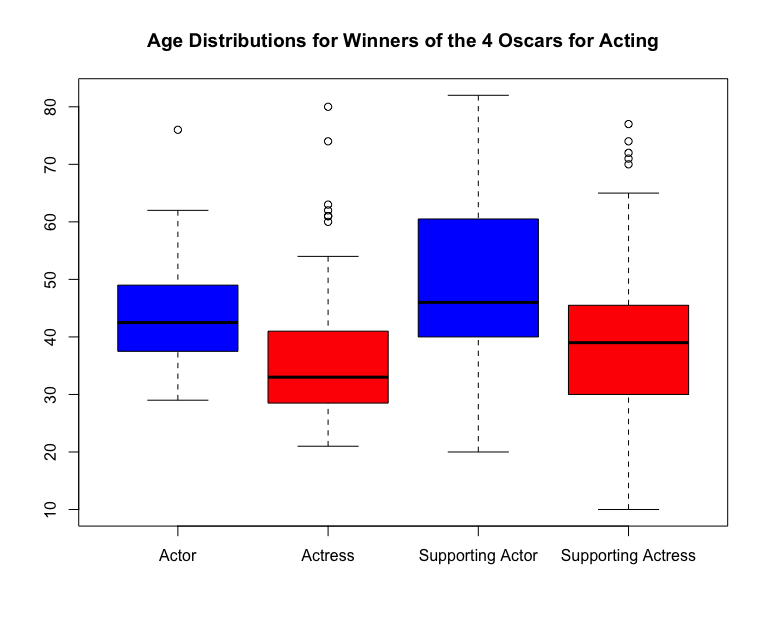

The boxplot suggests a clear difference in the ages at which one is likely to win an acting Oscar, depending on one’s gender. It seems that women are, on average, younger when they win their Oscars than men are. As discussed above, this effect could be emerging at a number of points along the pipeline. It could be that critics are more likely to recognize (i.e. vote for) the performances of younger female actors, whereas age may be less relevant for male actors. It could also be that this bias is present during the nomination process. Lastly, it could be that the film industry is such that the roles avaialbile for female actors that are ‘Oscar-worthy’ are for younger characters, thus it could be an issue of on the film production side.

#### Other

I have also included, just for fun, a table of all the films to have won 8 or more Oscars.

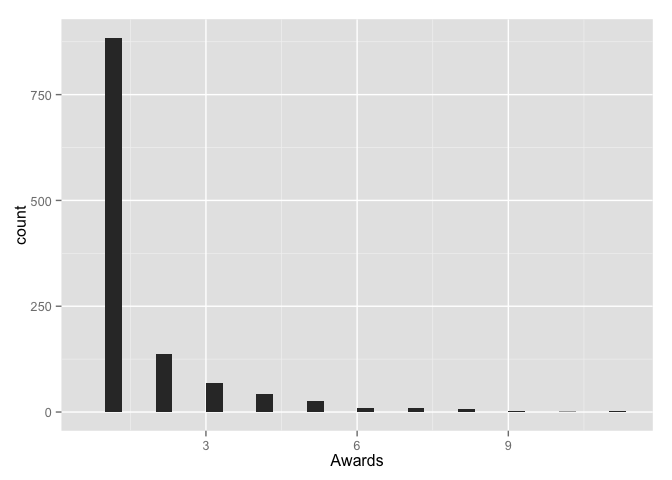

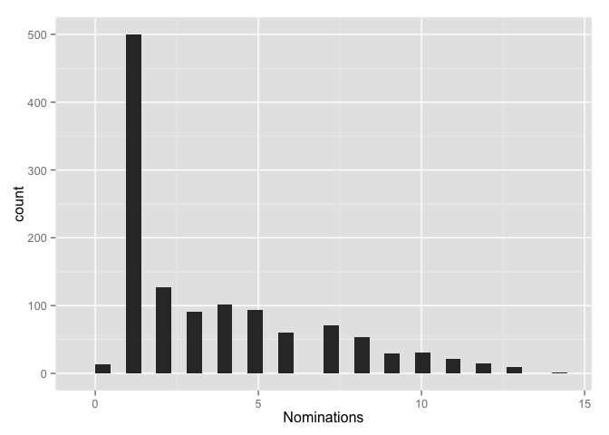

| Film | Year | Awards | Nominations |
| --- | --- | --- | --- |
| Amadeus | 1984 | 8 | 11 |
| Ben-Hur | 1959 | 11 | 12 |
| Cabaret | 1972 | 8 | 10 |
| English Patient, TheThe English Patient | 1996 | 9 | 12 |
| From Here to Eternity | 1953 | 8 | 13 |
| Gandhi | 1982 | 8 | 11 |
| Gigi | 1958 | 9 | 9 |
| Last Emperor, TheThe Last Emperor | 1987 | 9 | 9 |
| Lord of the Rings: The Return of the King, TheThe Lord of the Rings: The Return of the King | 2003 | 11 | 11 |
| My Fair Lady | 1964 | 8 | 12 |
| On the Waterfront | 1954 | 8 | 12 |
| Slumdog Millionaire | 2008 | 8 | 10 |
| Titanic | 1997 | 11 | 14 |
| West Side Story | 1961 | 10 | 11 |

## Conclusion

I believe the above results suggest that bias is indeed at play in the recognition of the accopmlishments of actors and film-makers. While a large portion of my time was devoted to tidying all of the necessary data and I was not able to adress all of my questions, there seems to be a clear differential treatment of male and female actors. Production budget may be less important in determining who wins an award, however, it is hard to say whether such factors may have an effect at other points in the pipeline.